# 07_FullData

J Andres Gannon, Erik Gartzke, and Jon Lindsay, Center for Peace and Security Studies (cPASS)

2019-01-06

This document compares case and variable coverage across all the Russia cyber data investigated.

The data comes from the following sources:

ICB comes from Brecher, Michael and Jonathan Wilkenfeld (2000). A Study of Crisis. Ann Arbor: University of Michigan Press.

DCID comes from Valeriano, B., & Maness, R. C. (2014). The dynamics of cyber conflict between rival antagonists, 2001–11. Journal of Peace Research, 51(3), 347–360. https://doi.org/10.1177/0022343313518940

REI comes from Casey, Adam; Way, Lucan Ahmad, 2017, “Russian Electoral Interventions, 1991-2017”, https://doi.org/10.5683/SP/BYRQQS, Scholars Portal Dataverse

# 1 Preparation

## 1.1 Load packages

Pipe operators have trouble loading for individual commands

```r
library(magrittr)
library(ggplot2)
```

## 1.2 Load data

Load the cleaned and subset versions of each dataset

```r
# Load data
cpass <- readRDS(paste0(here::here(), '/data/grayzone_cpass.rds'))
icb <- readRDS(paste0(here::here(), '/data/grayzone_icb.rds'))
dcid <- readRDS(paste0(here::here(), '/data/grayzone_dcid.rds'))
rei <- readRDS(paste0(here::here(), '/data/grayzone_rei.rds'))
```

# 2 Compare coverage

Before merging the data, compare the different cases covered by each one

## 2.1 Prep for coverage comparison

```r
# Create identifier variables for each dataset
cpass$cpass <- 1
icb$icb <- 1
dcid$dcid <- 1
rei$rei <- 1

# Ensure proper unit of analysis
dplyr::glimpse(cpass)
```

```
Observations: 10
Variables: 25
$ target                <chr> "Chechnya", "Kosovo", "Ukraine", "Canada", "United Kingdom", "Netherlands", "Saudi Arabia", "Ukraine", "United Kingdom...
$ year_start            <dbl> 1994, 1999, 2015, 2016, 2017, 2018, 2018, 2018, 2018, 2018
$ year_end              <dbl> 1996, 1999, NA, NA, NA, NA, NA, NA, NA, NA
$ fsu                   <dbl> 1, 0, 1, 0, 0, 0, 0, 1, 0, 0
$ det_dist_us_cap       <dbl> 5737, 4839, NA, NA, NA, NA, NA, NA, NA, NA
$ det_dist_us_cent      <dbl> 6154, 5650, NA, NA, NA, NA, NA, NA, NA, NA
$ det_dist_us_min       <dbl> 4936, 4083, NA, NA, NA, NA, NA, NA, NA, NA
$ det_dist_rus_cap      <dbl> 932, 1165, NA, NA, NA, NA, NA, NA, NA, NA
$ det_dist_rus_cent     <dbl> 2408, 3335, NA, NA, NA, NA, NA, NA, NA, NA
$ det_dist_rus_min      <dbl> 0, 760, NA, NA, NA, NA, NA, NA, NA, NA
$ det_alliance          <dbl> 0, 2, NA, NA, NA, NA, NA, NA, NA, NA
$ det_rusmiladv         <dbl> 1, 0, NA, NA, NA, NA, NA, NA, NA, NA
$ det_rustrade          <lgl> NA, NA, NA, NA, NA, NA, NA, NA, NA, NA
$ det_rusenergyexport   <lgl> NA, NA, NA, NA, NA, NA, NA, NA, NA, NA
$ det_eu                <dbl> 0.0, 0.5, NA, NA, NA, NA, NA, NA, NA, NA
$ det_rus_vitalinterest <dbl> 1, 0, NA, NA, NA, NA, NA, NA, NA, NA
$ resp_convmil          <dbl> 1, 1, 1, 0, 0, 0, 0, 1, 0, 0
$ resp_convmil_gro      <dbl> 1, 1, 1, 0, 0, 0, 0, 1, 0, 0
$ resp_convmil_airsea   <dbl> 1, 0, 1, 0, 0, 0, 0, 1, 0, 0
$ resp_paramil          <dbl> 1, 1, 1, 0, 0, 0, 0, 1, 0, 0
$ resp_cyberdisrup      <dbl> 1, 1, 1, 1, 1, 1, 1, 1, 1, 1
$ resp_infoops          <dbl> 1, 1, 1, 0, 0, 0, 0, 1, 0, 1
$ source                <chr> "https://www.rand.org/pubs/conf_proceedings/CF129/CF-129-chapter2.html; https://pdfs.semanticscholar.org/d00e/5952d606...
$ notes                 <chr> "Previously coded. Casualties believed to be around 100,000 - most of which were Chechen civilians. Sources provided."...
$ cpass                 <dbl> 1, 1, 1, 1, 1, 1, 1, 1, 1, 1
```

```r
dplyr::glimpse(icb)
```

```
Observations: 5
Variables: 14
$ `Crisis No`                  <int> 439, 445, 458, 471, 476
$ `Crisis Name`                <fct> PANKISI GORGE, S. OSSETIA/ABKHAZIA, RUSSO-GEORGIAN WAR, CRIMEA-DONBASS, TURKEY-RUSSIA JET INCIDENT
$ Year                         <int> 2002, 2004, 2008, 2014, 2015
$ Target                       <chr> "Georgia", "Georgia", "Georgia", "Ukraine", "Syria"
$ `Crisis Violence Centrality` <int> 2, 1, 3, 4, 1
$ `Crisis Violence Severity`   <int> 2, 1, 3, 3, 1
$ `Actor Violence Severity`    <int> 2, 1, 3, 3, 2
$ Escalation                   <dbl> 1, 1, 0, NA, NA
$ Outcome                      <chr> "Compromise", "Compromise", "Victory", "Victory", "Stalemate"
$ `Duration (days)`            <int> 72, 94, 9, 362, 2
$ Location                     <chr> "West Asia", "West Asia", "West Asia", "East Europe", "West Asia"
$ `Distance from Actor`        <chr> "Home territory", "Home territory", "Sub-region", "Sub-region", "Same continent"
$ `No. of Actors`              <int> 3, 3, 2, 5, 7
$ icb                          <dbl> 1, 1, 1, 1, 1
```

```r
dplyr::glimpse(dcid)
```

```
Observations: 45
Variables: 11
$ `Incident No.`      <dbl> 3, 5, 7, 9, 10, 11, 12, 13, 14, 15, 16, 81, 82, 83, 84, 85, 86, 87, 88, 89, 90, 91, 92, 93, 94, 95, 96, 97, 98, 99, 100,...
$ Incident            <chr> "Duke Series", "CENTCOM\\DOD (linked to APT 28)", "Sandworm", "Energetic Bear/Dragonfly/Crouching Yeti", "Operation Pawn...
$ Target              <chr> "US", "US", "US", "US", "US", "US", "US", "US", "US", "US", "US", "Canada", "Canada", "UK", "UK", "Poland", "Poland", "P...
$ `Start date`        <date> 2008-04-08, 2008-10-01, 2009-01-01, 2011-01-01, 2013-09-30, 2014-03-15, 2014-06-02, 2014-06-03, 2014-06-04, 2014-10-26,...
$ `End date`          <date> 2015-09-17, 2008-10-15, 2014-10-14, 2014-07-01, 2014-10-22, 2014-03-26, 2015-02-01, 2014-12-01, 2014-07-08, 2014-10-28,...
$ Type                <chr> "Offensive", "Offensive", "Offensive", "Offensive", "Nuisance", "Nuisance", "Offensive", "Offensive", "Nuisance", "Nuisa...
$ Method              <chr> "Infiltration: Virus", "Intrusion", "Intrusion", "Intrusion", "Intrusion", "DDoD", "Intrusion", "Intrusion", "Intrusion"...
$ Objective           <chr> "Long-term espionage", "Long-term espionage", "Long-term espionage", "Short-term espionage", "Short-term espionage", "Di...
$ Success             <dbl> 1, 1, 1, 1, 1, 1, 1, 1, 0, 1, 0, 1, 1, 1, 1, 1, 1, 1, 1, 1, 1, 1, 1, 1, 1, 1, 1, 1, 1, 1, 1, 1, 1, 1, 1, 1, 1, 1, 1, 1, ...
$ `Incident severity` <dbl> 4, 4, 4, 3, 4, 2, 4, 4, 3, 3, 3, 3, 2, 4, 2, 4, 3, 2, 2, 2, 2, 2, 4, 2, 2, 4, 2, 2, 2, 2, 2, 3, 2, 4, 2, 4, 3, 2, 2, 2, ...
$ dcid                <dbl> 1, 1, 1, 1, 1, 1, 1, 1, 1, 1, 1, 1, 1, 1, 1, 1, 1, 1, 1, 1, 1, 1, 1, 1, 1, 1, 1, 1, 1, 1, 1, 1, 1, 1, 1, 1, 1, 1, 1, 1, ...
```

```r
dplyr::glimpse(rei)
```

[output not shown]

```r
# Fix dcid dates to have a year column
dcid <- tidyr::separate(dcid, 'Start date', c("Start Year", "Start Month", "Start Day"), sep = "-")
dcid <- tidyr::separate(dcid, 'End date', c("End Year", "End Month", "End Day"), sep = "-")

# Rename merging variables to make things easier
cpass <- cpass %>% dplyr::rename('Target' = target,
                                 'Year' = year_start)

icb <- icb %>% dplyr::rename('Target' = Target,
                             'Year' = Year)

dcid <- dcid %>% dplyr::rename('Target' = Target,
                               'Year' = 'Start Year')

rei <- rei %>% dplyr::rename('Target' = Target,
                             'Year' = Year)

# Fix date types
cpass$Year <- as.numeric(cpass$Year)
icb$Year <- as.numeric(icb$Year)
dcid$Year <- as.numeric(dcid$Year)
rei$Year <- as.numeric(rei$Year)
```

## 2.2 Compare case coverage across datasets

```r
# Create dataframe versions of just variables to merge for the match
cpass_coverage <- cpass[ , c('Target', 'Year', 'cpass')]
icb_coverage <- icb[ , c('Target', 'Year', 'icb')]
dcid_coverage <- dcid[ , c('Target', 'Year', 'dcid')]
rei_coverage <- rei[ , c('Target', 'Year', 'rei')]

# Merge datasets with just ID vars
coverage <- dplyr::full_join(cpass_coverage, icb_coverage) %>% dplyr::full_join(., dcid_coverage) %>% dplyr::full_join(., rei_coverage)
```

```
Column `Target` has different attributes on LHS and RHS of join
```

```r
# Delete duplicates
coverage <- unique(coverage)

# Convert NAs to 0 to make table easier to read
coverage[is.na(coverage)] <- 0

# Sort chronologically
coverage <- coverage[order(coverage$Year, decreasing = FALSE), ]

# Make html table
formattable::formattable(coverage,
                         align = c("c", "c", "c", "c", "c", "c"),
                         list('cpass' = formattable::color_tile("transparent", "lightblue"),
                              'icb' = formattable::color_tile("transparent", "lightblue"),
                              'dcid' = formattable::color_tile("transparent", "lightblue"),
                              'rei' = formattable::color_tile("transparent", "lightblue")))
```

| Target | Year | cpass | icb | dcid | rei |
| --- | --- | --- | --- | --- | --- |
| Chechnya | 1994 | 1 | 0 | 0 | 0 |
| Belarus | 1994 | 0 | 0 | 0 | 1 |
| Ukraine | 1994 | 0 | 0 | 0 | 1 |
| Moldova | 1996 | 0 | 0 | 0 | 1 |
| Kosovo | 1999 | 1 | 0 | 0 | 0 |
| Georgia | 2002 | 0 | 1 | 0 | 0 |
| Ukraine | 2002 | 0 | 0 | 0 | 1 |
| Georgia | 2004 | 0 | 1 | 0 | 0 |
| Ukraine | 2004 | 0 | 0 | 0 | 1 |
| Lithuania | 2005 | 0 | 0 | 1 | 0 |
| Ukraine | 2005 | 0 | 0 | 1 | 0 |
| Moldova | 2005 | 0 | 0 | 0 | 1 |
| Belarus | 2006 | 0 | 0 | 0 | 1 |
| Estonia | 2007 | 0 | 0 | 1 | 0 |
| Georgia | 2007 | 0 | 0 | 1 | 0 |
| Georgia | 2008 | 0 | 1 | 1 | 0 |
| US | 2008 | 0 | 0 | 1 | 0 |
| Lithuania | 2008 | 0 | 0 | 1 | 0 |
| US | 2009 | 0 | 0 | 1 | 0 |
| Poland | 2009 | 0 | 0 | 1 | 0 |
| Ukraine | 2009 | 0 | 0 | 1 | 0 |
| Moldova | 2009 | 0 | 0 | 0 | 1 |
| Ukraine | 2010 | 0 | 0 | 0 | 1 |
| US | 2011 | 0 | 0 | 1 | 0 |
| Canada | 2011 | 0 | 0 | 1 | 0 |
| UK | 2011 | 0 | 0 | 1 | 0 |
| US | 2013 | 0 | 0 | 1 | 0 |
| Ukraine | 2013 | 0 | 0 | 1 | 0 |
| Ukraine | 2014 | 0 | 1 | 1 | 1 |
| US | 2014 | 0 | 0 | 1 | 0 |
| Canada | 2014 | 0 | 0 | 1 | 0 |
| UK | 2014 | 0 | 0 | 1 | 0 |
| Poland | 2014 | 0 | 0 | 1 | 0 |
| Moldova | 2014 | 0 | 0 | 0 | 1 |
| Ukraine | 2015 | 1 | 0 | 0 | 0 |
| Syria | 2015 | 0 | 1 | 0 | 0 |
| Germany | 2015 | 0 | 0 | 0 | 1 |
| United Kingdom | 2015 | 0 | 0 | 0 | 1 |
| Canada | 2016 | 1 | 0 | 0 | 0 |
| Austria | 2016 | 0 | 0 | 0 | 1 |
| Bulgaria | 2016 | 0 | 0 | 0 | 1 |
| Italy | 2016 | 0 | 0 | 0 | 1 |
| Montenegro | 2016 | 0 | 0 | 0 | 1 |
| Norway | 2016 | 0 | 0 | 0 | 1 |
| Netherlands | 2016 | 0 | 0 | 0 | 1 |
| United Kingdom | 2016 | 0 | 0 | 0 | 1 |
| United States | 2016 | 0 | 0 | 0 | 1 |
| United Kingdom | 2017 | 1 | 0 | 0 | 0 |
| Czech Republic | 2017 | 0 | 0 | 0 | 1 |
| France | 2017 | 0 | 0 | 0 | 1 |
| Germany | 2017 | 0 | 0 | 0 | 1 |
| Malta | 2017 | 0 | 0 | 0 | 1 |
| Netherlands | 2017 | 0 | 0 | 0 | 1 |
| Spain | 2017 | 0 | 0 | 0 | 1 |
| Netherlands | 2018 | 1 | 0 | 0 | 0 |
| Saudi Arabia | 2018 | 1 | 0 | 0 | 0 |
| Ukraine | 2018 | 1 | 0 | 0 | 0 |
| United Kingdom | 2018 | 1 | 0 | 0 | 0 |
| United States | 2018 | 1 | 0 | 0 | 0 |

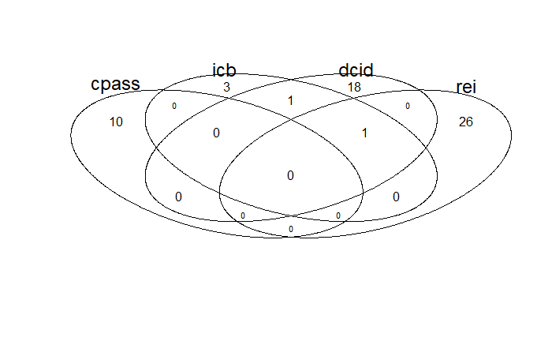

```r
# Make Venn diagram
coverage_venn <- coverage[ , c('cpass', 'icb', 'dcid', 'rei')]
gplots::venn(coverage_venn)
```

# 3 Merge data

## 3.1 Duplicates

First we identify the variables of interest in each dataset and those which are duplicates.

```r
# Add ICB merge
icb <- icb %>% dplyr::rename("icb_viol_crisis_cent" = "Crisis Violence Centrality",
                                  "icb_viol_crisis_sev" = "Crisis Violence Severity",
                                  "icb_viol_actor_sev" = "Actor Violence Severity")
icb_join <- icb[ , c('Year', 'Target', 'icb_viol_crisis_cent', 'icb_viol_crisis_sev', 'icb_viol_actor_sev', 'icb')]

# Rename the dcid severity variable so we know the source
dcid <- dcid %>% dplyr::rename("dcid_severity" = "Incident severity")
dcid_join <- dcid[ , c('Target', 'Year', 'dcid', 'Incident', 'dcid_severity')]

# Rename the rei variables so we know the source
rei <- rei %>% dplyr::rename(
  "rei_infoops" = "Disinformation campaign",
  "rei_cyberdisrup" = "Cyberattack",
  "rei_matsupp" = "Material support")

rei_join <- rei[ , c('Target', 'Year', 'rei', 'rei_infoops', 'rei_cyberdisrup', 'rei_matsupp')]
```

## 3.2 Merge

Merge the old datasets into a single dataframe so they can uploaded to a googlesheet and new variables can be coded.

```r
# Merge datasets with just ID vars
cases_old <- dplyr::full_join(icb_join, dcid_join) %>% dplyr::full_join(., rei_join)
```

```
Column `Target` has different attributes on LHS and RHS of join
```

```r
# Delete duplicates
cases_old <- unique(cases_old)

# Sort chronologically
cases_old <- cases_old[order(cases_old$Year, decreasing = FALSE), ]
```

# 4 Save final dataframe

This dataframe should now match the one in the google doc for old_cases. SOme duplicate country-years will be merged assuming all other values are identical. They can now have new variables added for our coding of the severity of Russian actions

```r
saveRDS(cases_old, paste0(here::here(), "/data/","grayzone_old.rds"))
write.csv(cases_old, paste0(here::here(), "/data/","grayzone_old.csv"))
```

# 5 Reload dataframe with new variables coded

## 5.1 Clean for merge

The new variables for intensity have been coded by hand into the previous spreadsheet. That can be reloaded now and nerged with the new cases that were similarly coded to analyze the complete version of the dataset. The variables from the new data need to match up with their equivalents in the old data. We’ll change the old data to match it up

```r
df_complete <- googlesheets::gs_title("Russian wars")
```

```
Sheet successfully identified: "Russian wars"
```

```r
df_new <- df_complete %>% googlesheets::gs_read("new_cases")
```

```
Accessing worksheet titled 'new_cases'.
```

```
Downloading: 990 B
Downloading: 990 B
Downloading: 1 kB
Downloading: 1 kB
Downloading: 1 kB
Downloading: 1 kB
```

```r
df_old <- df_complete %>% googlesheets::gs_read("old_cases")
```

```
Accessing worksheet titled 'old_cases'.
```

```
Downloading: 1.2 kB
Downloading: 1.2 kB
Downloading: 8.8 kB
Downloading: 8.8 kB
Downloading: 8.8 kB
Downloading: 8.8 kB
```

```r
# Clean data for a clean merge
colnames(df_new)
```

```
 [1] "target"                "year_start"            "year_end"              "fsu"                   "det_dist_us_cap"       "det_dist_us_cent"
 [7] "det_dist_us_min"       "det_dist_rus_cap"      "det_dist_rus_cent"     "det_dist_rus_min"      "det_alliance"          "det_rusmiladv"
[13] "det_rustrade"          "det_rusenergyexport"   "det_eu"                "det_rus_vitalinterest" "resp_convmil"          "resp_convmil_gro"
[19] "resp_convmil_airsea"   "resp_paramil"          "resp_cyberdisrup"      "resp_infoops"          "source"                "notes"
```

```r
colnames(df_old)
```

```
 [1] "Incident"            "Target"              "Year"                "dcid"                "rei"                 "det_alliance"
 [7] "resp_convmil"        "resp_convmil_gro"    "resp_convmil_airsea" "resp_paramil"        "resp_cyberdisrup"    "resp_infoops"
[13] "source"              "notes"               "dcid_severity"       "rei_infoops"         "rei_cyberdisrup"     "rei_matsupp"
```

```r
# Fix variables names
df_new$new <- 1
df_old <- df_old %>% dplyr::rename("incident" = "Incident",
                                   "target" = "Target",
                                   "year_start" = "Year")
```

## 5.2 Merge

```r
# Merge the old and new cases inot a single dataframe
cases_all <- dplyr::full_join(df_new, df_old)
# Sort by date
cases_all <- cases_all[order(cases_all$year_start, decreasing = FALSE), ]

# Inspect quality
summary(cases_all)
```

```
    target            year_start      year_end         fsu       det_dist_us_cap det_dist_us_cent det_dist_us_min det_dist_rus_cap det_dist_rus_cent
 Length:82          Min.   :1994   Min.   :1996   Min.   :0.00   Min.   :4839    Min.   :5650     Min.   :4083    Min.   : 932.0   Min.   :2408
 Class :character   1st Qu.:2008   1st Qu.:1997   1st Qu.:0.00   1st Qu.:5064    1st Qu.:5776     1st Qu.:4296    1st Qu.: 990.2   1st Qu.:2640
 Mode  :character   Median :2014   Median :1998   Median :0.00   Median :5288    Median :5902     Median :4510    Median :1048.5   Median :2872
                    Mean   :2011   Mean   :1998   Mean   :0.30   Mean   :5288    Mean   :5902     Mean   :4510    Mean   :1048.5   Mean   :2872
                    3rd Qu.:2016   3rd Qu.:1998   3rd Qu.:0.75   3rd Qu.:5512    3rd Qu.:6028     3rd Qu.:4723    3rd Qu.:1106.8   3rd Qu.:3103
                    Max.   :2018   Max.   :1999   Max.   :1.00   Max.   :5737    Max.   :6154     Max.   :4936    Max.   :1165.0   Max.   :3335
                                   NA's   :80     NA's   :72     NA's   :80      NA's   :80       NA's   :80      NA's   :80       NA's   :80
 det_dist_rus_min  det_alliance  det_rusmiladv  det_rustrade   det_rusenergyexport     det_eu      det_rus_vitalinterest  resp_convmil
 Min.   :  0      Min.   :0.00   Min.   :0.00   Mode:logical   Mode:logical        Min.   :0.000   Min.   :0.00          Min.   :0.0000
 1st Qu.:190      1st Qu.:1.00   1st Qu.:0.25   NA's:82        NA's:82             1st Qu.:0.125   1st Qu.:0.25          1st Qu.:0.0000
 Median :380      Median :1.00   Median :0.50                                      Median :0.250   Median :0.50          Median :0.0000
 Mean   :380      Mean   :1.50   Mean   :0.50                                      Mean   :0.250   Mean   :0.50          Mean   :0.2625
 3rd Qu.:570      3rd Qu.:2.25   3rd Qu.:0.75                                      3rd Qu.:0.375   3rd Qu.:0.75          3rd Qu.:1.0000
 Max.   :760      Max.   :3.00   Max.   :1.00                                      Max.   :0.500   Max.   :1.00          Max.   :1.0000
 NA's   :80       NA's   :62     NA's   :80                                        NA's   :80      NA's   :80            NA's   :2
 resp_convmil_gro resp_convmil_airsea  resp_paramil    resp_cyberdisrup  resp_infoops       source             notes                new
 Min.   :0.000    Min.   :0.0000      Min.   :0.0000   Min.   :1        Min.   :0.0000   Length:82          Length:82          Min.   :1
 1st Qu.:0.000    1st Qu.:0.0000      1st Qu.:0.0000   1st Qu.:1        1st Qu.:0.0000   Class :character   Class :character   1st Qu.:1
 Median :0.000    Median :0.0000      Median :0.0000   Median :1        Median :1.0000   Mode  :character   Mode  :character   Median :1
 Mean   :0.200    Mean   :0.2278      Mean   :0.2658   Mean   :1        Mean   :0.7027                                         Mean   :1
 3rd Qu.:0.125    3rd Qu.:0.0000      3rd Qu.:1.0000   3rd Qu.:1        3rd Qu.:1.0000                                         3rd Qu.:1
 Max.   :1.000    Max.   :1.0000      Max.   :1.0000   Max.   :1        Max.   :1.0000                                         Max.   :1
 NA's   :2        NA's   :3           NA's   :3        NA's   :9        NA's   :8                                              NA's   :72
   incident              dcid         rei     dcid_severity    rei_infoops     rei_cyberdisrup   rei_matsupp
 Length:82          Min.   :1    Min.   :1    Min.   :1.000   Min.   :0.0000   Min.   :0.0000   Min.   :0.0000
 Class :character   1st Qu.:1    1st Qu.:1    1st Qu.:2.000   1st Qu.:0.0000   1st Qu.:0.0000   1st Qu.:0.0000
 Mode  :character   Median :1    Median :1    Median :2.500   Median :1.0000   Median :1.0000   Median :0.0000
                    Mean   :1    Mean   :1    Mean   :2.762   Mean   :0.5161   Mean   :0.5161   Mean   :0.4194
                    3rd Qu.:1    3rd Qu.:1    3rd Qu.:4.000   3rd Qu.:1.0000   3rd Qu.:1.0000   3rd Qu.:1.0000
                    Max.   :1    Max.   :1    Max.   :4.000   Max.   :1.0000   Max.   :1.0000   Max.   :1.0000
                    NA's   :40   NA's   :51   NA's   :40      NA's   :51       NA's   :51       NA's   :51
```

```r
# Drop columns we're not using now
vars_keep <- c("target",
               "year_start",
               "resp_convmil",
               "resp_convmil_gro",
               "resp_convmil_airsea",
               "resp_paramil",
               "resp_cyberdisrup",
               "resp_infoops",
               "source",
               "notes",
               "new",
               "incident",
               "dcid",
               "rei",
               "dcid_severity",
               "rei_infoops",
               "rei_cyberdisrup",
               "rei_matsupp")

cases_all <- cases_all[ , vars_keep]

#Save
saveRDS(cases_all, paste0(here::here(), "/data/","grayzone_aggregate_cpass.rds"))
write.csv(cases_all, paste0(here::here(), "/data/","grayzone_aggregate_cpass.csv"))
```